# Expansión de la CASEN sobre el CENSO (Región 08)

### 1.1.2 Cálculo de frecuencias

Obtenemos las frecuencias a la pregunta ESCOLARIDAD por zona:

```r
tabla_con_clave_f <- tabla_con_clave[,c("clave","ESCOLARIDAD","COMUNA") ]
```

```r
names(tabla_con_clave_f)[2] <- "ESCOLARIDAD"
```

```r
tabla_con_clave_ff <- filter(tabla_con_clave_f, tabla_con_clave_f$ESCOLARIDAD == 14)
```

```r
# Determinamos las frecuencias por zona:
b <- tabla_con_clave_ff$clave
c <- tabla_con_clave_ff$ESCOLARIDAD
d <- tabla_con_clave_ff$COMUNA
cross_tab =  xtabs( ~ unlist(b) + unlist(c)+ unlist(d))
tabla <- as.data.frame(cross_tab)
d <-tabla[!(tabla$Freq == 0),]
names(d)[1] <- "zona"
d$anio <- "2017"

head(d,5)
```

```
##         zona unlist.c. unlist.d. Freq anio
## 1 8101252025        14      8101    1 2017
## 2 8101292012        14      8101    1 2017
## 3 8101292020        14      8101    4 2017
## 4 8101292023        14      8101    1 2017
## 5 8101302001        14      8101    4 2017
```

Agregamos un cero a los códigos comunales de cuatro dígitos:

```r
codigos <- d$unlist.d.
rango <- seq(1:nrow(d))
cadena <- paste("0",codigos[rango], sep = "")
cadena <- substr(cadena,(nchar(cadena)[rango])-(4),6)
codigos <- as.data.frame(codigos)
cadena <- as.data.frame(cadena)
comuna_corr <- cbind(d,cadena)
comuna_corr <- comuna_corr[,-c(2,3),drop=FALSE]
names(comuna_corr)[4] <- "código"
```

### 1.1.3 Tabla de frecuencias:

```r
head(comuna_corr,5)
```

```
##         zona Freq anio código
## 1 8101252025    1 2017  08101
## 2 8101292012    1 2017  08101
## 3 8101292020    4 2017  08101
## 4 8101292023    1 2017  08101
## 5 8101302001    4 2017  08101
```

## 1.2 Variable CASEN

### 1.2.1 Tabla de ingresos expandidos

Hemos calculado ya éste valor como conclusión del punto 1.1 de [aquí](https://rpubs.com/dataintelligence/corr_casen_censo_002)

```r
h_y_m_2017_censo <- readRDS("../ingresos_expandidos_rural_17.rds")
tablamadre <- head(h_y_m_2017_censo,50)
kbl(tablamadre) %>%
  kable_styling(bootstrap_options = c("striped", "hover")) %>%
  kable_paper() %>%
  scroll_box(width = "100%", height = "300px")
```

|  | código | personas | comuna | promedio_i | año | ingresos_expandidos |
| --- | --- | --- | --- | --- | --- | --- |
| 1 | 01101 | 191468 | Iquique | 272529.7 | 2017 | 52180713221 |
| 3 | 01401 | 15711 | Pozo Almonte | 243272.4 | 2017 | 3822052676 |
| 4 | 01402 | 1250 | Camiña | 226831.0 | 2017 | 283538750 |
| 6 | 01404 | 2730 | Huara | 236599.7 | 2017 | 645917134 |
| 7 | 01405 | 9296 | Pica | 269198.0 | 2017 | 2502464414 |
| 10 | 02103 | 10186 | Sierra Gorda | 322997.9 | 2017 | 3290056742 |
| 11 | 02104 | 13317 | Taltal | 288653.8 | 2017 | 3844002134 |
| 12 | 02201 | 165731 | Calama | 238080.9 | 2017 | 39457387800 |
| 14 | 02203 | 10996 | San Pedro de Atacama | 271472.6 | 2017 | 2985112297 |
| 15 | 02301 | 25186 | Tocopilla | 166115.9 | 2017 | 4183793832 |
| 17 | 03101 | 153937 | Copiapó | 251396.0 | 2017 | 38699138722 |
| 19 | 03103 | 14019 | Tierra Amarilla | 287819.4 | 2017 | 4034940816 |
| 21 | 03202 | 13925 | Diego de Almagro | 326439.0 | 2017 | 4545663075 |
| 22 | 03301 | 51917 | Vallenar | 217644.6 | 2017 | 11299454698 |
| 23 | 03302 | 5299 | Alto del Carmen | 196109.9 | 2017 | 1039186477 |
| 24 | 03303 | 7041 | Freirina | 202463.8 | 2017 | 1425547554 |
| 25 | 03304 | 10149 | Huasco | 205839.6 | 2017 | 2089066548 |
| 26 | 04101 | 221054 | La Serena | 200287.4 | 2017 | 44274327972 |
| 27 | 04102 | 227730 | Coquimbo | 206027.8 | 2017 | 46918711304 |
| 28 | 04103 | 11044 | Andacollo | 217096.4 | 2017 | 2397612293 |
| 29 | 04104 | 4241 | La Higuera | 231674.2 | 2017 | 982530309 |
| 30 | 04105 | 4497 | Paiguano | 174868.5 | 2017 | 786383423 |
| 31 | 04106 | 27771 | Vicuña | 169077.1 | 2017 | 4695441470 |
| 32 | 04201 | 30848 | Illapel | 165639.6 | 2017 | 5109649759 |
| 33 | 04202 | 9093 | Canela | 171370.3 | 2017 | 1558270441 |
| 34 | 04203 | 21382 | Los Vilos | 173238.5 | 2017 | 3704185607 |
| 35 | 04204 | 29347 | Salamanca | 193602.0 | 2017 | 5681637894 |
| 36 | 04301 | 111272 | Ovalle | 230819.8 | 2017 | 25683781418 |
| 37 | 04302 | 13322 | Combarbalá | 172709.2 | 2017 | 2300832587 |
| 38 | 04303 | 30751 | Monte Patria | 189761.6 | 2017 | 5835357638 |
| 39 | 04304 | 10956 | Punitaqui | 165862.0 | 2017 | 1817183694 |
| 40 | 04305 | 4278 | Río Hurtado | 182027.2 | 2017 | 778712384 |
| 41 | 05101 | 296655 | Valparaíso | 251998.5 | 2017 | 74756602991 |
| 42 | 05102 | 26867 | Casablanca | 252317.7 | 2017 | 6779018483 |
| 45 | 05105 | 18546 | Puchuncaví | 231606.0 | 2017 | 4295363979 |
| 46 | 05107 | 31923 | Quintero | 285125.8 | 2017 | 9102071069 |
| 49 | 05301 | 66708 | Los Andes | 280548.0 | 2017 | 18714795984 |
| 50 | 05302 | 14832 | Calle Larga | 234044.6 | 2017 | 3471349123 |
| 51 | 05303 | 10207 | Rinconada | 246136.9 | 2017 | 2512319225 |
| 52 | 05304 | 18855 | San Esteban | 211907.3 | 2017 | 3995512770 |
| 53 | 05401 | 35390 | La Ligua | 172675.9 | 2017 | 6111000517 |
| 54 | 05402 | 19388 | Cabildo | 212985.0 | 2017 | 4129354103 |
| 56 | 05404 | 9826 | Petorca | 270139.8 | 2017 | 2654393853 |
| 57 | 05405 | 7339 | Zapallar | 235661.4 | 2017 | 1729518700 |
| 58 | 05501 | 90517 | Quillota | 212067.6 | 2017 | 19195726144 |
| 59 | 05502 | 50554 | Calera | 226906.2 | 2017 | 11471016698 |
| 60 | 05503 | 17988 | Hijuelas | 215402.0 | 2017 | 3874650405 |
| 61 | 05504 | 22098 | La Cruz | 243333.4 | 2017 | 5377180726 |
| 62 | 05506 | 22120 | Nogales | 219800.7 | 2017 | 4861992055 |
| 63 | 05601 | 91350 | San Antonio | 230261.5 | 2017 | 21034388728 |

## 1.3 Unión Censo-Casen:

y creamos la columna multipob:

```r
comunas_censo_casen = merge( x = comuna_corr, y = h_y_m_2017_censo, by = "código", all.x = TRUE)
comunas_censo_casen <- comunas_censo_casen[,-c(4)]
head(comunas_censo_casen,5)
```

```
##   código       zona Freq personas     comuna promedio_i  año
## 1  08101 8101302011   13   223574 Concepción   197625.8 2017
## 2  08101 8101302018    1   223574 Concepción   197625.8 2017
## 3  08101 8101302901    5   223574 Concepción   197625.8 2017
## 4  08101 8101312001    8   223574 Concepción   197625.8 2017
## 5  08101 8101312004    1   223574 Concepción   197625.8 2017
##   ingresos_expandidos
## 1         44183983882
## 2         44183983882
## 3         44183983882
## 4         44183983882
## 5         44183983882
```

## 1.4 Unión de la proporcion zonal por comuna con la tabla censo-casen:

unimos a nuestra tabla de proporciones zonales por comuna:

Para calcular la variable multipob, debemos multiplicarla por su proporcion zonal respecto a la comunal.

Del censo obtenemos la cantidad de población a nivel de zona y estimamos su proporción a nivel comunal. Ya hemos calculado ésta proporción [aquí](https://rpubs.com/dataintelligence/tabla_de_proporciones).

## 1.5 Ingreso promedio expandido por zona (**multi_pob**)

En éste momento vamos a construir nuestra variable dependiente de regresión aplicando la siguiente fórmula:

$$multi\_pob = promedio\_i \cdot personas \cdot p\_poblacional$$

```r
tabla_de_prop_pob <- readRDS("../tabla_de_prop_pob.rds")
names(tabla_de_prop_pob)[1]  <- "zona"
```

```r
comunas_censo_casen = merge( x = comunas_censo_casen, y = tabla_de_prop_pob, by = "zona", all.x = TRUE)
head(comunas_censo_casen,5)
```

```
##         zona código.x Freq.x personas     comuna promedio_i  año
## 1 8101252025    08101      1   223574 Concepción   197625.8 2017
## 2 8101292012    08101      1   223574 Concepción   197625.8 2017
## 3 8101292020    08101      4   223574 Concepción   197625.8 2017
## 4 8101292023    08101      1   223574 Concepción   197625.8 2017
## 5 8101302001    08101      4   223574 Concepción   197625.8 2017
##   ingresos_expandidos Freq.y            p código.y
## 1         44183983882     60 0.0002683675    08101
## 2         44183983882     86 0.0003846601    08101
## 3         44183983882     61 0.0002728403    08101
## 4         44183983882     54 0.0002415308    08101
## 5         44183983882    280 0.0012523818    08101
```

```r
comunas_censo_casen$multipob <- comunas_censo_casen$ingresos_expandidos*comunas_censo_casen$p
```

```r
head(comunas_censo_casen,5)
```

```
##         zona código.x Freq.x personas     comuna promedio_i  año
## 1 8101252025    08101      1   223574 Concepción   197625.8 2017
## 2 8101292012    08101      1   223574 Concepción   197625.8 2017
## 3 8101292020    08101      4   223574 Concepción   197625.8 2017
## 4 8101292023    08101      1   223574 Concepción   197625.8 2017
## 5 8101302001    08101      4   223574 Concepción   197625.8 2017
##   ingresos_expandidos Freq.y            p código.y multipob
## 1         44183983882     60 0.0002683675    08101 11857546
## 2         44183983882     86 0.0003846601    08101 16995816
## 3         44183983882     61 0.0002728403    08101 12055172
## 4         44183983882     54 0.0002415308    08101 10671792
## 5         44183983882    280 0.0012523818    08101 55335216
```

## 1.6 Análisis de regresión

Aplicaremos un análisis de regresión donde:

$$Y(dependiente) = ingreso \ expandido \ por \ zona \ (multi\_pob)$$

$$X(independiente) = frecuencia \ de \ población \ que \ posee \ la \ variable \ Censal \ respecto \ a \ la \ zona \ (Freq.x)$$

### 1.6.1 Diagrama de dispersión loess

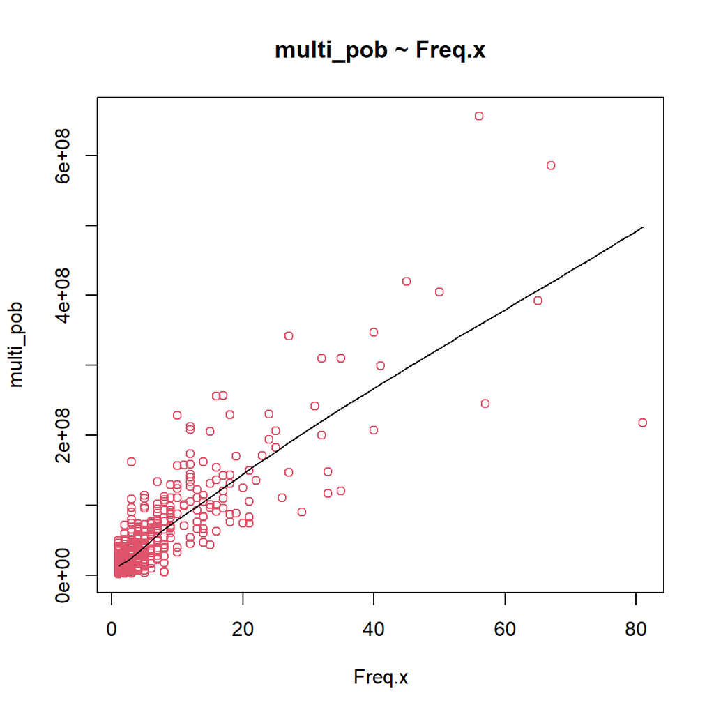

```r
scatter.smooth(x=comunas_censo_casen$Freq.x, y=comunas_censo_casen$multipob, main="multi_pob ~ Freq.x",
     xlab = "Freq.x",
     ylab = "multi_pob",
           col = 2)
```

### 1.6.2 Outliers

Hemos demostrado en el punto 5.7.2 de [aquí](https://rpubs.com/dataintelligence/expansion_personas_001) que la exclusión de ouliers no genera ninguna mejora en el modelo de regresión.

### 1.6.3 Modelo lineal

Aplicaremos un análisis de regresión lineal del ingreso expandido por zona sobre las frecuencias de respuestas zonales.

```r
linearMod <- lm( multipob~(Freq.x) , data=comunas_censo_casen)
summary(linearMod)
```

```
##
## Call:
## lm(formula = multipob ~ (Freq.x), data = comunas_censo_casen)
##
## Residuals:
##        Min         1Q     Median         3Q        Max
## -325662294  -13531420   -5402802    9564238  278010503
##
## Coefficients:
##             Estimate Std. Error t value Pr(>|t|)
## (Intercept) 10324730    1686460   6.122 1.66e-09 ***
## Freq.x       6582585     161133  40.852  < 2e-16 ***
## ---
## Signif. codes:  0 '***' 0.001 '**' 0.01 '*' 0.05 '.' 0.1 ' ' 1
##
## Residual standard error: 34970000 on 608 degrees of freedom
##   (9 observations deleted due to missingness)
## Multiple R-squared:  0.733,  Adjusted R-squared:  0.7325
## F-statistic:  1669 on 1 and 608 DF,  p-value: < 2.2e-16
```

### 1.6.4 Gráfica de la recta de regresión lineal

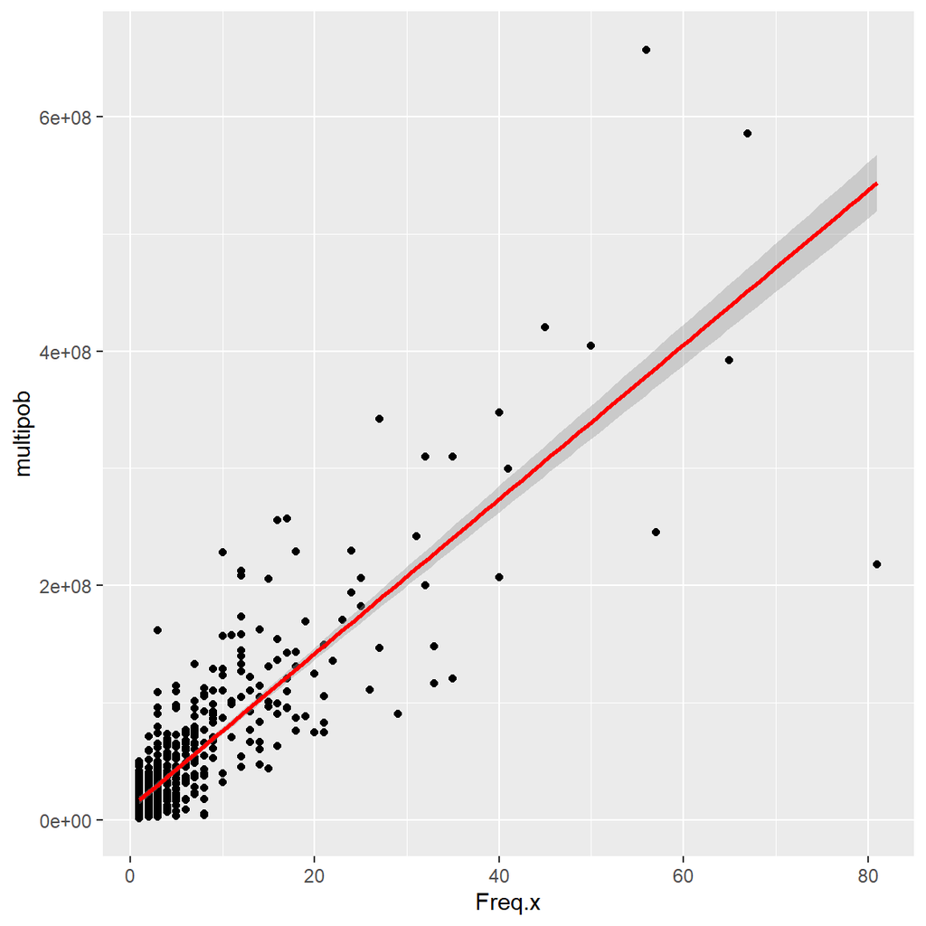

```r
ggplot(comunas_censo_casen, aes(x = Freq.x , y = multipob)) +
  geom_point() +
  stat_smooth(method = "lm", col = "red")
```

## 1.7 Modelos alternativos

```r
### 8.1 Modelo cuadrático

linearMod <- lm( multipob~(Freq.x^2) , data=comunas_censo_casen)
datos <- summary(linearMod)
dato <- datos$adj.r.squared
modelo <- "cuadrático"
sintaxis <- "linearMod <- lm( multi_pob~(Freq.x^2) , data=h_y_m_comuna_corr_01)"

modelos1 <- cbind(modelo,dato,sintaxis)


modelos1 <- cbind(modelo,dato,sintaxis)

### 8.2 Modelo cúbico

linearMod <- lm( multipob~(Freq.x^3) , data=comunas_censo_casen)
datos <- summary(linearMod)
dato <- datos$adj.r.squared
modelo <- "cúbico"
sintaxis <- "linearMod <- lm( multi_pob~(Freq.x^3) , data=h_y_m_comuna_corr_01)"

modelos2 <- cbind(modelo,dato,sintaxis)

### 8.3 Modelo logarítmico

linearMod <- lm( multipob~log(Freq.x) , data=comunas_censo_casen)
datos <- summary(linearMod)
dato <- datos$adj.r.squared
modelo <- "logarítmico"
sintaxis <- "linearMod <- lm( multi_pob~log(Freq.x) , data=h_y_m_comuna_corr_01)"

modelos3 <- cbind(modelo,dato,sintaxis)

### 8.5 Modelo con raíz cuadrada

linearMod <- lm( multipob~sqrt(Freq.x) , data=comunas_censo_casen)
datos <- summary(linearMod)
dato <- datos$adj.r.squared
modelo <- "raíz cuadrada"
sintaxis <- "linearMod <- lm( multi_pob~sqrt(Freq.x) , data=h_y_m_comuna_corr_01)"

modelos5 <- cbind(modelo,dato,sintaxis)

### 8.6 Modelo raíz-raíz

linearMod <- lm( sqrt(multipob)~sqrt(Freq.x) , data=comunas_censo_casen)
datos <- summary(linearMod)
dato <- datos$adj.r.squared
modelo <- "raíz-raíz"
sintaxis <- "linearMod <- lm( sqrt(multi_pob)~sqrt(Freq.x) , data=h_y_m_comuna_corr_01)"

modelos6 <- cbind(modelo,dato,sintaxis)

### 8.7 Modelo log-raíz

linearMod <- lm( log(multipob)~sqrt(Freq.x) , data=comunas_censo_casen)
datos <- summary(linearMod)
dato <- datos$adj.r.squared
modelo <- "log-raíz"
sintaxis <- "linearMod <- lm( log(multi_pob)~sqrt(Freq.x) , data=h_y_m_comuna_corr_01)"

modelos7 <- cbind(modelo,dato,sintaxis)

### 8.8 Modelo raíz-log

linearMod <- lm( sqrt(multipob)~log(Freq.x) , data=comunas_censo_casen)
datos <- summary(linearMod)
dato <- datos$adj.r.squared
modelo <- "raíz-log"
sintaxis <- "linearMod <- lm( sqrt(multi_pob)~log(Freq.x) , data=h_y_m_comuna_corr_01)"

modelos8 <- cbind(modelo,dato,sintaxis)

### 8.9 Modelo log-log

linearMod <- lm( log(multipob)~log(Freq.x) , data=comunas_censo_casen)
datos <- summary(linearMod)
dato <- datos$adj.r.squared
modelo <- "log-log"
sintaxis <- "linearMod <- lm( log(multi_pob)~log(Freq.x) , data=h_y_m_comuna_corr_01)"

modelos9 <- cbind(modelo,dato,sintaxis)

modelos_bind <- rbind(modelos1, modelos2,modelos3,modelos5,modelos6,modelos7,modelos8,modelos9)
modelos_bind <- as.data.frame(modelos_bind)

modelos_bind <<- modelos_bind[order(modelos_bind$dato, decreasing = T ),]
h_y_m_comuna_corr_01 <<- comunas_censo_casen

kbl(modelos_bind) %>%
  kable_styling(bootstrap_options = c("striped", "hover")) %>%
  kable_paper() %>%
  scroll_box(width = "100%", height = "300px")
```

|  | modelo | dato | sintaxis |
| --- | --- | --- | --- |
| 5 | raíz-raíz | 0.735190706178707 | linearMod <- lm( sqrt(multi_pob)~sqrt(Freq.x) , data=h_y_m_comuna_corr_01) |
| 1 | cuadrático | 0.732528312828263 | linearMod <- lm( multi_pob~(Freq.x^2) , data=h_y_m_comuna_corr_01) |
| 2 | cúbico | 0.732528312828263 | linearMod <- lm( multi_pob~(Freq.x^3) , data=h_y_m_comuna_corr_01) |
| 4 | raíz cuadrada | 0.704425343090495 | linearMod <- lm( multi_pob~sqrt(Freq.x) , data=h_y_m_comuna_corr_01) |
| 7 | raíz-log | 0.673911537022858 | linearMod <- lm( sqrt(multi_pob)~log(Freq.x) , data=h_y_m_comuna_corr_01) |
| 8 | log-log | 0.609472771561497 | linearMod <- lm( log(multi_pob)~log(Freq.x) , data=h_y_m_comuna_corr_01) |
| 6 | log-raíz | 0.568792599226549 | linearMod <- lm( log(multi_pob)~sqrt(Freq.x) , data=h_y_m_comuna_corr_01) |
| 3 | logarítmico | 0.548202342738502 | linearMod <- lm( multi_pob~log(Freq.x) , data=h_y_m_comuna_corr_01) |

Elegimos el 5 pues tiene el ma alto $R^2$

```r
h_y_m_comuna_corr <- h_y_m_comuna_corr_01
metodo <- 5


switch (metodo,
        case = linearMod <- lm( multipob~(Freq.x^2) , data=h_y_m_comuna_corr),
        case = linearMod <- lm( multipob~(Freq.x^3) , data=h_y_m_comuna_corr),
        case = linearMod <- lm( multipob~log(Freq.x) , data=h_y_m_comuna_corr),
        case = linearMod <- lm( multipob~sqrt(Freq.x) , data=h_y_m_comuna_corr),
        case = linearMod <- lm( sqrt(multipob)~sqrt(Freq.x) , data=h_y_m_comuna_corr),
        case = linearMod <- lm( log(multipob)~sqrt(Freq.x) , data=h_y_m_comuna_corr),
        case = linearMod <- lm( sqrt(multipob)~log(Freq.x) , data=h_y_m_comuna_corr),
        case = linearMod <- lm( log(multipob)~log(Freq.x) , data=h_y_m_comuna_corr)
)
summary(linearMod)
```

```
##
## Call:
## lm(formula = sqrt(multipob) ~ sqrt(Freq.x), data = h_y_m_comuna_corr)
##
## Residuals:
##     Min      1Q  Median      3Q     Max
## -8199.8 -1243.1  -144.9  1101.2  7521.3
##
## Coefficients:
##              Estimate Std. Error t value Pr(>|t|)
## (Intercept)    949.59     141.79   6.697 4.84e-11 ***
## sqrt(Freq.x)  2445.56      59.46  41.131  < 2e-16 ***
## ---
## Signif. codes:  0 '***' 0.001 '**' 0.01 '*' 0.05 '.' 0.1 ' ' 1
##
## Residual standard error: 1867 on 608 degrees of freedom
##   (9 observations deleted due to missingness)
## Multiple R-squared:  0.7356, Adjusted R-squared:  0.7352
## F-statistic:  1692 on 1 and 608 DF,  p-value: < 2.2e-16
```

```r
aa <- linearMod$coefficients[1]
aa
```

```
## (Intercept)
##    949.5944
```

```r
bb <- linearMod$coefficients[2]
bb
```

```
## sqrt(Freq.x)
##     2445.561
```

## Modelo raíz-raíz (**raíz-raíz**)

Es éste el modelo que nos entrega el mayor coeficiente de determinación de todos (0.7352).

### 1.7.1 Diagrama de dispersión sobre **raíz-raíz**

Desplegamos una curva suavizada por loess en el diagrama de dispersión.

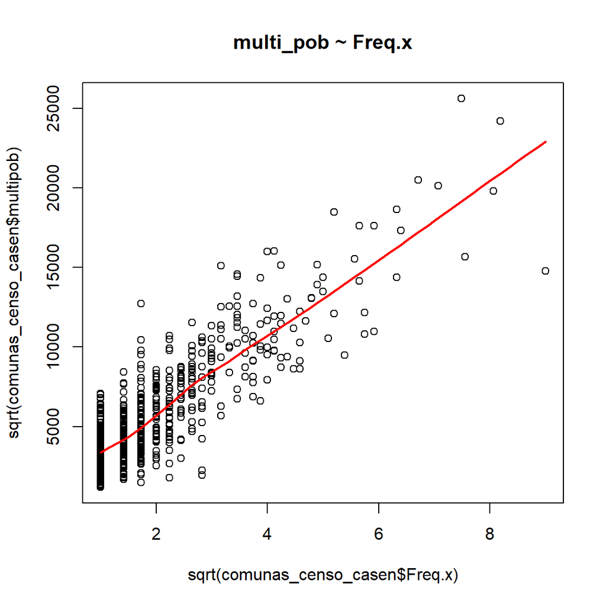

```r
scatter.smooth(x=sqrt(comunas_censo_casen$Freq.x), y=sqrt(comunas_censo_casen$multipob), lpars = list(col = "red", lwd = 2, lty = 1), main="multi_pob ~ Freq.x")
```

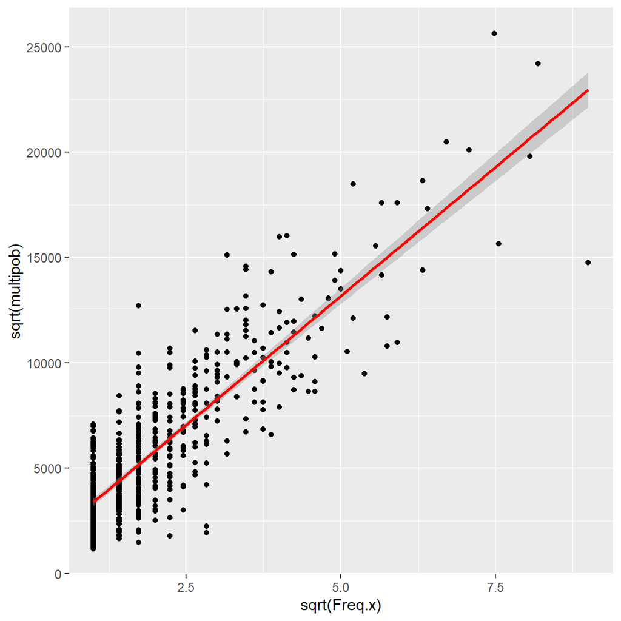

```r
ggplot(comunas_censo_casen, aes(x = sqrt(Freq.x) , y = sqrt(multipob))) + geom_point() + stat_smooth(method = "lm", col = "red")
```

### 1.7.2 Análisis de residuos

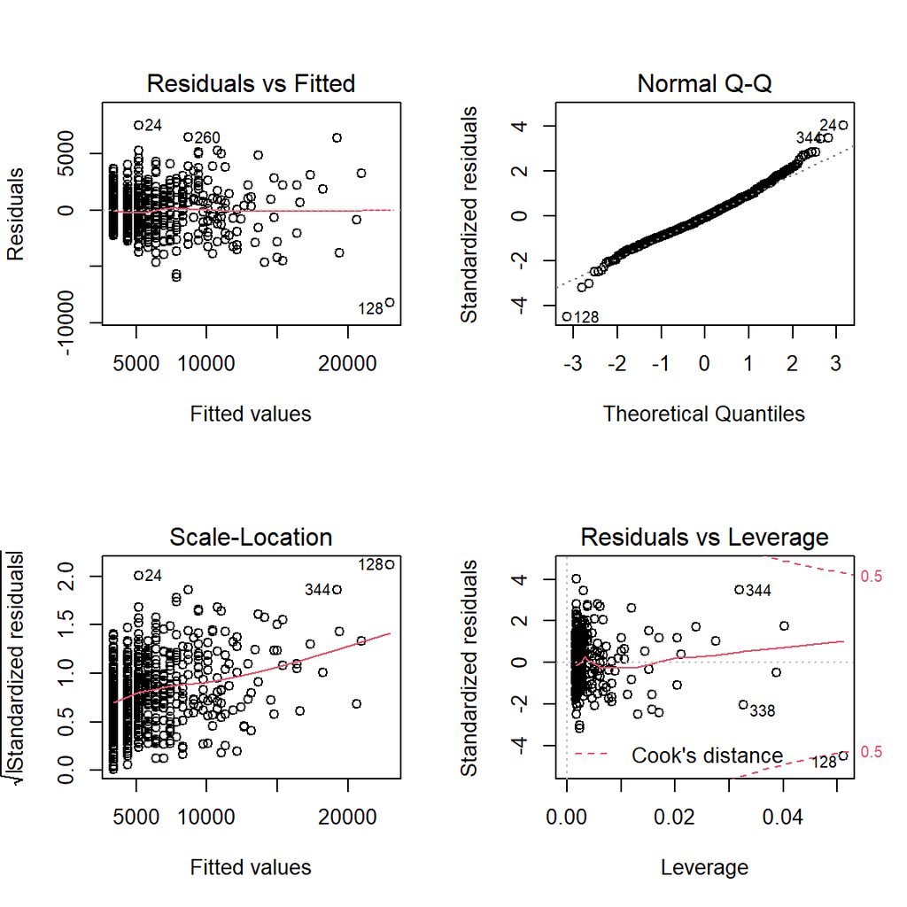

```r
par(mfrow = c (2,2))
plot(linearMod)
```

Modelo raíz-raíz

## 1.8 10 Aplicación la regresión a los valores de la variable a nivel de zona

Esta nueva variable se llamará: est_ing

```r
h_y_m_comuna_corr$est_ing  = { aa}^2 + 2  * aa  * bb * sqrt(h_y_m_comuna_corr$Freq.x)+   bb^2 * (h_y_m_comuna_corr$Freq.x)
```

## 1.9 11 División del valor estimado entre la población total de la zona para obtener el ingreso medio por zona

$$Ingreso \_ Medio\_zona = est\_ing / (personas * p\_poblacional)$$

```r
h_y_m_comuna_corr$ing_medio_zona <- h_y_m_comuna_corr$est_ing  /( h_y_m_comuna_corr$personas  * h_y_m_comuna_corr$p)

r3_100 <- h_y_m_comuna_corr[c(1:100),]
kbl(r3_100) %>%
  kable_styling(bootstrap_options = c("striped", "hover")) %>%
  kable_paper() %>%
  scroll_box(width = "100%", height = "300px")
```

| zona | código.x | Freq.x | personas | comuna | promedio_i | año | ingresos_expandidos | Freq.y | p | código.y | multipob | est_ing | ing_medio_zona |
| --- | --- | --- | --- | --- | --- | --- | --- | --- | --- | --- | --- | --- | --- |
| 8101252025 | 08101 | 1 | 223574 | Concepción | 197625.8 | 2017 | 44183983882 | 60 | 0.0002684 | 08101 | 11857546 | 11527077 | 192117.96 |
| 8101292012 | 08101 | 1 | 223574 | Concepción | 197625.8 | 2017 | 44183983882 | 86 | 0.0003847 | 08101 | 16995816 | 11527077 | 134035.78 |
| 8101292020 | 08101 | 4 | 223574 | Concepción | 197625.8 | 2017 | 44183983882 | 61 | 0.0002728 | 08101 | 12055172 | 34113958 | 559245.21 |
| 8101292023 | 08101 | 1 | 223574 | Concepción | 197625.8 | 2017 | 44183983882 | 54 | 0.0002415 | 08101 | 10671792 | 11527077 | 213464.39 |
| 8101302001 | 08101 | 4 | 223574 | Concepción | 197625.8 | 2017 | 44183983882 | 280 | 0.0012524 | 08101 | 55335216 | 34113958 | 121835.56 |
| 8101302005 | 08101 | 16 | 223574 | Concepción | 197625.8 | 2017 | 44183983882 | 688 | 0.0030773 | 08101 | 135966530 | 115172319 | 167401.63 |
| 8101302008 | 08101 | 2 | 223574 | Concepción | 197625.8 | 2017 | 44183983882 | 98 | 0.0004383 | 08101 | 19367325 | 19431692 | 198282.58 |
| 8101302011 | 08101 | 13 | 223574 | Concepción | 197625.8 | 2017 | 44183983882 | 469 | 0.0020977 | 08101 | 92686486 | 95397970 | 203407.19 |
| 8101302018 | 08101 | 1 | 223574 | Concepción | 197625.8 | 2017 | 44183983882 | 51 | 0.0002281 | 08101 | 10078914 | 11527077 | 226021.12 |
| 8101302019 | 08101 | 5 | 223574 | Concepción | 197625.8 | 2017 | 44183983882 | 198 | 0.0008856 | 08101 | 39129902 | 41191162 | 208036.17 |
| 8101302021 | 08101 | 7 | 223574 | Concepción | 197625.8 | 2017 | 44183983882 | 401 | 0.0017936 | 08101 | 79247934 | 55055502 | 137295.52 |
| 8101302901 | 08101 | 5 | 223574 | Concepción | 197625.8 | 2017 | 44183983882 | 16 | 0.0000716 | 08101 | 3162012 | 41191162 | 2574447.59 |
| 8101312001 | 08101 | 8 | 223574 | Concepción | 197625.8 | 2017 | 44183983882 | 90 | 0.0004026 | 08101 | 17786319 | 61884721 | 687608.01 |
| 8101312004 | 08101 | 1 | 223574 | Concepción | 197625.8 | 2017 | 44183983882 | 63 | 0.0002818 | 08101 | 12450424 | 11527077 | 182969.48 |
| 8101312013 | 08101 | 25 | 223574 | Concepción | 197625.8 | 2017 | 44183983882 | 1045 | 0.0046741 | 08101 | 206518930 | 173643799 | 166166.31 |
| 8101312014 | 08101 | 21 | 223574 | Concepción | 197625.8 | 2017 | 44183983882 | 534 | 0.0023885 | 08101 | 105532161 | 147781971 | 276745.26 |
| 8101312017 | 08101 | 4 | 223574 | Concepción | 197625.8 | 2017 | 44183983882 | 47 | 0.0002102 | 08101 | 9288411 | 34113958 | 725828.90 |
| 8101322025 | 08101 | 3 | 223574 | Concepción | 197625.8 | 2017 | 44183983882 | 100 | 0.0004473 | 08101 | 19762577 | 26888680 | 268886.80 |
| 8102062004 | 08102 | 1 | 116262 | Coronel | 217018.1 | 2017 | 25230952648 | 29 | 0.0002494 | 08102 | 6293523 | 11527077 | 397485.42 |
| 8102062005 | 08102 | 18 | 116262 | Coronel | 217018.1 | 2017 | 25230952648 | 350 | 0.0030104 | 08102 | 75956318 | 128260816 | 366459.47 |
| 8102062009 | 08102 | 21 | 116262 | Coronel | 217018.1 | 2017 | 25230952648 | 382 | 0.0032857 | 08102 | 82900895 | 147781971 | 386863.80 |
| 8102072005 | 08102 | 22 | 116262 | Coronel | 217018.1 | 2017 | 25230952648 | 624 | 0.0053672 | 08102 | 135419264 | 154263610 | 247217.32 |
| 8102092010 | 08102 | 6 | 116262 | Coronel | 217018.1 | 2017 | 25230952648 | 298 | 0.0025632 | 08102 | 64671379 | 48163183 | 161621.42 |
| 8102102007 | 08102 | 3 | 116262 | Coronel | 217018.1 | 2017 | 25230952648 | 744 | 0.0063993 | 08102 | 161461430 | 26888680 | 36140.70 |
| 8102102011 | 08102 | 3 | 116262 | Coronel | 217018.1 | 2017 | 25230952648 | 503 | 0.0043264 | 08102 | 109160080 | 26888680 | 53456.62 |
| 8102112006 | 08102 | 2 | 116262 | Coronel | 217018.1 | 2017 | 25230952648 | 55 | 0.0004731 | 08102 | 11935993 | 19431692 | 353303.50 |
| 8102112008 | 08102 | 5 | 116262 | Coronel | 217018.1 | 2017 | 25230952648 | 104 | 0.0008945 | 08102 | 22569877 | 41191162 | 396068.86 |
| 8103062006 | 08103 | 2 | NA | NA | NA | NA | NA | 65 | 0.0007564 | 08103 | NA | 19431692 | NA |
| 8104012015 | 08104 | 3 | 10624 | Florida | 147425.2 | 2017 | 1566245750 | 61 | 0.0057417 | 08104 | 8992940 | 26888680 | 440798.03 |
| 8104012023 | 08104 | 3 | 10624 | Florida | 147425.2 | 2017 | 1566245750 | 163 | 0.0153426 | 08104 | 24030314 | 26888680 | 164961.23 |

[output cut: 70 more lines]

Guardamos:

```r
saveRDS(h_y_m_comuna_corr, "Rural/region_08_ESCOLARIDAD_r.rds")
```

## 1.10 Referencias

https://rpubs.com/osoramirez/316691

https://dataintelligencechile.shinyapps.io/casenfinal

Manual_de_usuario_Censo_2017_16R.pdf

http://www.censo2017.cl/microdatos/

Censo de Población y Vivienda

https://www.ine.cl/estadisticas/sociales/censos-de-poblacion-y-vivienda/poblacion-y-vivienda

http://r-statistics.co/Linear-Regression.html